```python
import pandas as pd
import matplotlib.pyplot as plt
import seaborn as sns
import numpy as np
import jieba
from snownlp import SnowNLP
import pyecharts.options as opts
from pyecharts.charts import WordCloud
from pyecharts.charts import Map
import html5lib
import warnings
warnings.filterwarnings("ignore")
```

```python
boss=pd.read_csv('./data/boss岗位.csv',encoding='utf8')
```

```python
plt.rcParams['font.sans-serif']='SimHei'
```

# 对地区进行处理，把它分成城市、城区和街道三个部分并保存到数据中

```python
boss['城市']=[i.split('·')[0] for i in boss.地区]
boss['城区']='null'
boss['街道']='null'
for i in boss['地区'].index:
    try:
        boss['城区'][i]=boss['地区'][i].split('·')[1]
        boss['街道'][i]=boss['地区'][i].split('·')[2]
    except:
        boss['城区'][i]='nan'
        boss['街道'][i]='nan'
```

# 对薪资进行处理，保留去除年终奖的部分，并转换成统一的每个月工资

```python
for i in boss['薪资'].index:
    try:
        boss['薪资'][i]=boss['薪资'][i].split('·')[0]
    except:
        pass
for i in boss['薪资'].index:
    if 'K' in boss['薪资'][i]:
        min=boss['薪资'][i].replace('K','').split('-')[0]
        max=boss['薪资'][i].replace('K','').split('-')[1]
        boss['薪资'][i]=((int(min)*1000)+(int(max)*1000))/2
    elif '元/天' in boss['薪资'][i]:
        try:
            min=boss['薪资'][i].replace('元/天','').split('-')[0]
            max=boss['薪资'][i].replace('元/天','').split('-')[1]
            boss['薪资'][i]=((int(min)+int(max))/2)*30
        except:
            max=boss['薪资'][i].replace('元/天','')
            boss['薪资'][i]=float(max)*30
    elif '元/时' in boss['薪资'][i]:
        min=boss['薪资'][i].replace('元/时','').split('-')[0]
        max=boss['薪资'][i].replace('元/时','').split('-')[1]
        boss['薪资'][i]=(((int(min)*8)+(int(max)*8))/2)*30
    elif '元/月' in boss['薪资'][i]:
        min=boss['薪资'][i].replace('元/月','').split('-')[0]
        max=boss['薪资'][i].replace('元/月','').split('-')[1]
        boss['薪资'][i]=(int(min)+int(max))/2
```

# 对学历进行处理，仅保留大专、本科等这一部分

```python
boss['经验']=[i[-2:] for i in boss['经验']]
```

# 筛选出发出招聘信息的部分城市

```python
cs=pd.DataFrame()
cs=cs.append(boss['城市'].value_counts())
cs=cs.T
cs=cs[cs['城市']>=50]
```

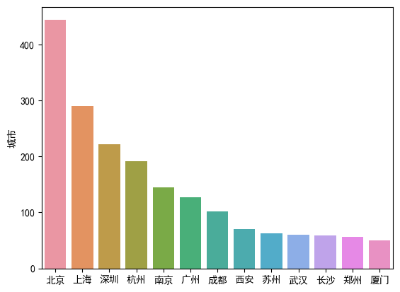

```python
sns.barplot(data=cs,x=cs.index,y='城市')
plt.show()
```

```python
gs_bj=pd.DataFrame()
gs_bj=gs_bj.append(boss[boss['城市']=='北京']['公司名'].value_counts())
gs_bj=gs_bj.T
```

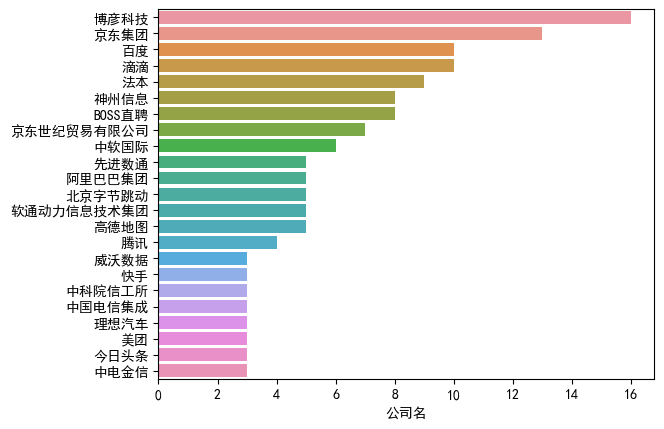

```python
gs_bj=gs_bj[gs_bj['公司名']>2]
sns.barplot(data=gs_bj,y=gs_bj.index,x='公司名')
plt.show()
```

而在北京的公司中，各公司的招人数量如图显示，此图形是经过数据筛选的，还有很多仅要1-2人的公司没有显示。

```python
b=pd.DataFrame()
b=b.append(boss['标题'].value_counts())
b=b.T
```

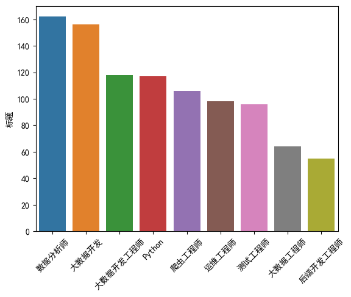

```python
b=b[b['标题']>50]
sns.barplot(data=b,x=b.index,y='标题')
plt.xticks(rotation=45)
plt.show()
```

这是全部招聘信息中的岗位，可以看出，数据分析师和大数据开发工程师很吃香。

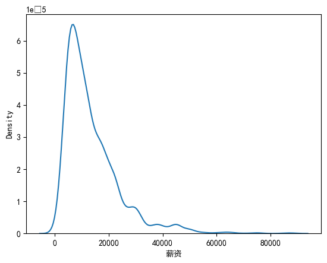

```python
sns.kdeplot(data=boss,x='薪资')
plt.show()
```

每份招聘信息的薪资水平分布图，大部分的薪资提供在每个月1w左右。

```python
jp=pd.DataFrame()
jp=jp.append(boss['经验'].value_counts())
jp=jp.T
```

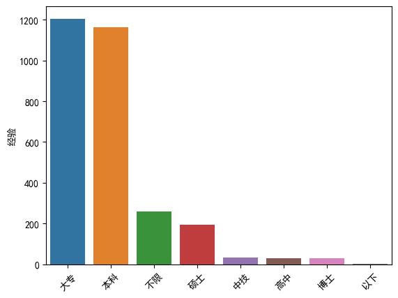

```python
sns.barplot(data=jp,x=jp.index,y='经验')
plt.xticks(rotation=45)
plt.show()
```

各个公司对岗位的学历需求，其中大专和本科学历的人员需求远超其他学历，甚至大专学历的需求高与本科学历，说明很多公司看重的更多是实操能力，能马上上岗工作在找工作的过程中更吃香。

```python
dz=pd.DataFrame()
dz=dz.append(boss[boss['经验']=='大专']['标题'].value_counts())
dz=dz.T
dz=dz[dz['标题']>=20]

dz_xz=pd.DataFrame()
dz_xz=dz_xz.append(boss[boss['经验']=='大专']['薪资'].value_counts())
dz_xz=dz_xz.T
dz_xz=dz_xz[dz_xz['薪资']>40]
dz_xz=dz_xz.sort_values(by='薪资',ascending=False)

dz_gs=pd.DataFrame()
dz_gs=dz_gs.append(boss[boss['经验']=='大专']['公司名'].value_counts())
dz_gs=dz_gs.T
dz_gs=dz_gs[dz_gs['公司名']>4]

dz_dq=pd.DataFrame()
dz_dq=dz_dq.append(boss[boss['经验']=='大专']['城市'].value_counts())
dz_dq=dz_dq.T
dz_dq=dz_dq[dz_dq['城市']>=20]
```

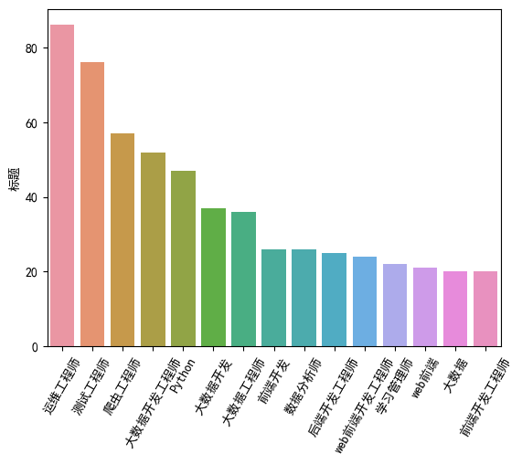

```python
sns.barplot(data=dz,x=dz.index,y='标题')
plt.xticks(rotation=60)
plt.show()
```

各公司需要的员工中学历为大专的工作岗位，靠前的为运维工程师、测试工程师和爬虫工程师，这几个工作岗位都需要一定的特点技能，符合大多数公司看重的更多是实操能力这个点。

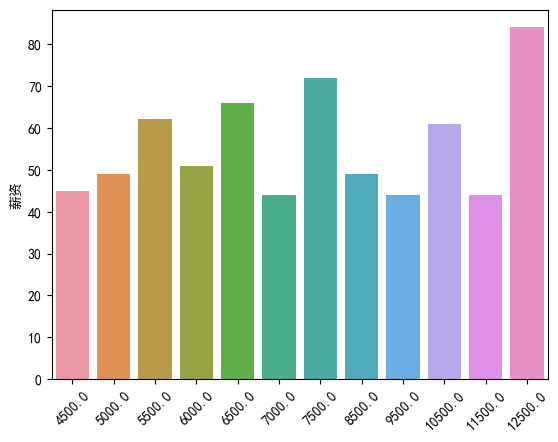

```python
sns.barplot(data=dz_xz,x=dz_xz.index,y='薪资')
plt.xticks(rotation=45)
plt.show()
```

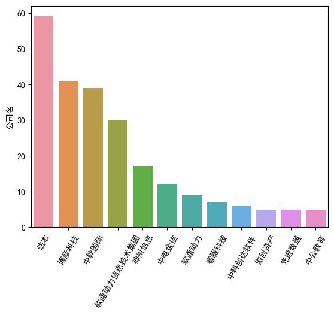

```python
sns.barplot(data=dz_gs,x=dz_gs.index,y='公司名')
plt.xticks(rotation=60)
plt.show()
```

这是招聘大专的前12个公司

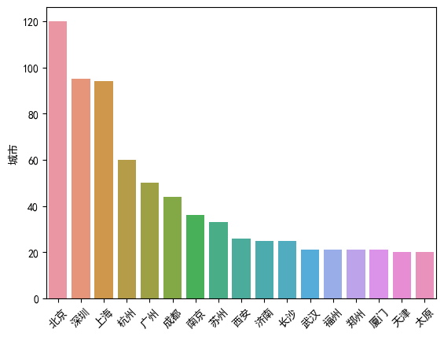

```python
sns.barplot(data=dz_dq,x=dz_dq.index,y='城市')
plt.xticks(rotation=45)
plt.show()
```

```python
可以看到北京、深圳和上海这几个经济中心所招聘的大专生是最多的。
```

```python
words=[]
for i in boss['福利'].index:
    try:
        words=words+boss['福利'][i].split('，')
    except:
        pass
```

```python
word_count = {}
for word in words:
    if word not in word_count:
        word_count[word] = 1
    else:
        word_count[word] += 1
```

```python
wordcloud = (WordCloud()
    .add("", list(word_count.items()), word_size_range=[20, 100], shape='circle')
    .set_global_opts(title_opts=opts.TitleOpts(title="词云图"))
)
wordcloud.render("wordcloud.html")
```

```
'C:\\Users\\LEGION\\Desktop\\实训3\\python\\wordcloud.html'
```

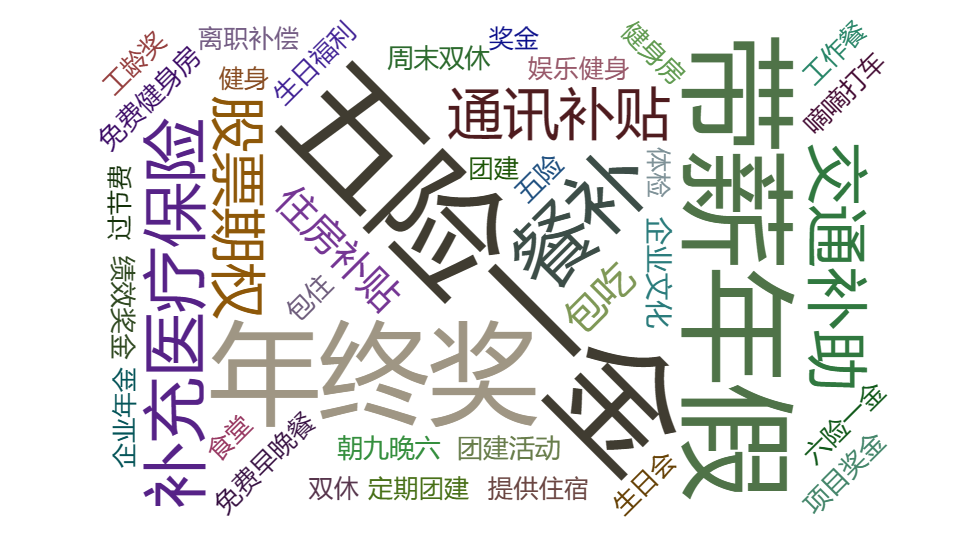

通过各公司所以供的福利做出来的词云图，可以看到‘五险一金’数量最多，说明现在的很多公司都有五险一金的保障，紧随其后的是‘年终奖’和‘带薪年假’，都是不错的待遇。

```python
dq=[]
dq=[i.split('·')[0] for i in boss.地区]
```

```python
dq_count=[]
for i in dq:
    if i not in dq_count:
        dq_count.append(i)
data=[]
for i in dq_count:
    data.append((i,dq.count(i)))
```

```python
map_chart = (
    Map()
    .add("城市", data, "china",)
    .set_global_opts(
        title_opts=opts.TitleOpts(title="中国地图"),
        visualmap_opts=opts.VisualMapOpts(max_=200),

    )
)

# 设置地图的渲染方式
map_chart.render("china_map.html")
```

```
'C:\\Users\\LEGION\\Desktop\\实训3\\python\\china_map.html'
```

[figure not shown]